# Prosper Loan Data Presentation

## by Shinyui Chu

## Investigation Overview

> The goal of this inbestigation is to find out the factors that might affect loan APR and outcome

## Dataset Overview

> This data set contains 113,937 loans with 81 variables on each loan, including loan amount, borrower rate (or interest rate), current loan status, borrower income, and many others.

## APR Comparison of Homeowners

> After the investigation we found out that one of the factor that will affect APR is whether the borrower is homeowner or not. It seems like those who are houseowners tends to have lower APR than those who aren't. The reason behind this phenomenon could be the landing club can take house as collateral, hence they won't need to take much risks than those who don't have house.

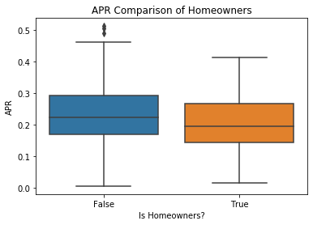

```python
sns.boxplot(x=df_extracted["IsBorrowerHomeowner"], y=df_extracted["BorrowerAPR"])
plt.xlabel("Is Homeowners?")
plt.ylabel("APR")
plt.title("APR Comparison of Homeowners");
```

## Loan Status Comparision of Homeowner

> On the other hand we also found out that whether the borrower is homeowner or not will also affect the loan status. From the loan status count plot below we can see that the number of loan's being declared defaulted, chargedoff, or pass due, the non-homeowner's loan seems to have a higher possibilities to become defaulted, chargedoff or pastdue.

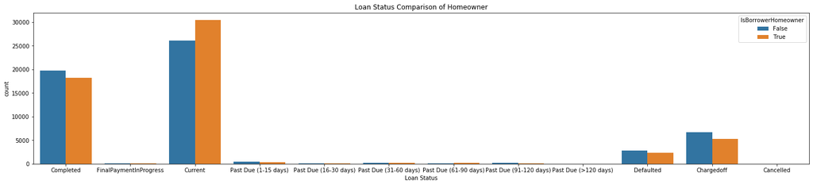

```python
loan_status_order = ['Completed', 'FinalPaymentInProgress', 'Current',
                     'Past Due (1-15 days)',
                     'Past Due (16-30 days)',
                     'Past Due (31-60 days)',
                     'Past Due (61-90 days)',
                     'Past Due (91-120 days)',
                     'Past Due (>120 days)',
                     'Defaulted','Chargedoff', 'Cancelled']

df_extracted['LoanStatus'] = pd.Categorical(df_extracted['LoanStatus'],
                                            categories=loan_status_order,
                                            ordered = True)
plt.figure(figsize=(25, 5))
sns.countplot(df_extracted["LoanStatus"], hue=df_extracted["IsBorrowerHomeowner"])
plt.xlabel("Loan Status")
plt.title("Loan Status Comparison of Homeowner");
```

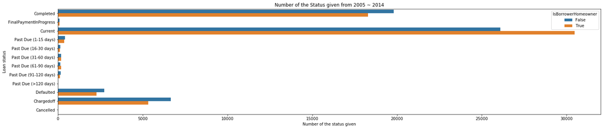

```python
loan_status_order = ['Completed', 'FinalPaymentInProgress', 'Current',
                     'Past Due (1-15 days)',
                     'Past Due (16-30 days)',
                     'Past Due (31-60 days)',
                     'Past Due (61-90 days)',
                     'Past Due (91-120 days)',
                     'Past Due (>120 days)',
                     'Defaulted','Chargedoff', 'Cancelled']

df_extracted['LoanStatus'] = pd.Categorical(df_extracted['LoanStatus'],
                                            categories=loan_status_order,
                                            ordered = True)
plt.figure(figsize=(25, 5))
sns.countplot(y=df_extracted["LoanStatus"], hue=df_extracted["IsBorrowerHomeowner"])
plt.xlabel("Number of the status given")
plt.ylabel("Loan status")
plt.title("Number of the Status given from 2005 ~ 2014");
```

```python
!jupyter nbconvert presentation.ipynb --to slides --post serve --template output_toggle
```

[output not shown]